# The Depressed Brain: An Evolutionary Systems Theory - ScienceDirect

## Outline

[figure not shown]

[figure not shown]

[figure not shown]

[figure not shown]

## Trends in Cognitive Sciences

[Volume 21, Issue 3](https://www.sciencedirect.com/journal/trends-in-cognitive-sciences/vol/21/issue/3), March 2017, Pages 182-194

# Opinion The Depressed Brain: An Evolutionary Systems Theory

[Paul B.Badcock<sup>1</sup><sup>2</sup><sup>3</sup>](https://www.sciencedirect.com/science/article/pii/S1364661317300050#!)[Christopher G.Davey<sup>1</sup><sup>3</sup>](https://www.sciencedirect.com/science/article/pii/S1364661317300050#!)[SarahWhittle<sup>2</sup><sup>4</sup>](https://www.sciencedirect.com/science/article/pii/S1364661317300050#!)[Nicholas B.Allen<sup>5</sup>](https://www.sciencedirect.com/science/article/pii/S1364661317300050#!)[Karl J.Friston<sup>6</sup><sup>7</sup>](https://www.sciencedirect.com/author/36080215500/k-j-friston)

https://doi.org/10.1016/j.tics.2017.01.005[Get rights and content](https://s100.copyright.com/AppDispatchServlet?publisherName=ELS&contentID=S1364661317300050&orderBeanReset=true)

## Trends

The free-energy principle (FEP) is a theory of brain function asserting that action and perception operate synergistically to minimise surprise and resolve uncertainty.

Recent applications to depression have focussed on maladaptive states, concentrating either on bottom-up deficits in predictive processing or on top-down deficits in reward processing.

The relevance of evolutionary systems theory (EST) has been largely overlooked, with theorists neglecting to ask whether our capacity for depressed mood reflects an adaptive response to specific ecological challenges.

In psychology, converging lines of evidence suggest that depression stems from a need to navigate adverse social contexts.

We synthesise these paradigms (FEP and EST) by arguing that depression reflects an adaptive strategy that responds to threats of aversive interpersonal outcomes by resolving uncertainty in the social world.

Major depression is a debilitating condition characterised by diverse neurocognitive and behavioural deficits. Nevertheless, our species-typical capacity for depressed mood implies that it serves an adaptive function. Here we apply an interdisciplinary theory of brain function to explain depressed mood and its clinical manifestations. Combining insights from the free-energy principle (FEP) with evolutionary theorising in psychology, we argue that depression reflects an adaptive response to perceived threats of aversive social outcomes (e.g., exclusion) that minimises the likelihood of surprising interpersonal exchanges (i.e., those with unpredictable outcomes). We suggest that psychopathology typically arises from ineffectual attempts to alleviate interpersonal difficulties and/or hyper-reactive neurobiological responses to social stress (i.e., uncertainty), which often stems from early experience that social uncertainty is difficult to resolve.

## An Evolutionary Systems Approach to Depression

Why do we become depressed? Why are some of us particularly prone to depression? How is this best managed? To answer these questions, we require an interdisciplinary approach that synthesises studies of the depressed brain with psychological research on its ecological, developmental, and biobehavioural correlates 1, 2. To this end, we apply an integrative **evolutionary systems theory (EST)** (see Glossary) of human brain function to explain depressed mood and its clinical manifestations. The EST in question rests on two uncontroversial assumptions. The first appeals to a consensus among cognitive scientists that the brain is a hierarchical, self-organising system sculpted by evolution 3, 4, 5. This hierarchy ranges from lower-order, highly specialised neural subsystems responsible for sensory–motor processing to highly integrated cortical regions that develop more gradually and underlie the sophisticated, executive cognitive faculties unique to humans (Box 1). This calls for a theory of global brain function that explains how depression emerges from coordinated interactions within hierarchically integrated neuronal systems. The second assumption echoes dynamic systems approaches that situate the brain within the evolutionary dynamics of the brain–body–environment system 6, 7, 8. According to this view, the neural mechanisms responsible for depression can be understood only by considering the broader context of human evolution, enculturation, development, embodiment, and behaviour.

Box 1

The Hierarchical Structure of the Brain

In psychology, it has long been recognised that the brain entails a hierarchical structure ranging from highly specialised sensorimotor systems at its lowest levels to developmentally flexible, highly integrated systems responsible for higher-order executive functions 3, 72. A hierarchical neural architecture is also emphasised by predictive coding approaches in neuroscience, which explore how the brain minimises prediction error via recurrent message passing between cortical levels 9, 73, 74. More recently, imaging studies in network neuroscience have provided direct evidence that the brain exhibits a multiscale hierarchical organisation, with a given node (e.g., network, module, submodule) itself comprising a network of smaller interacting nodes at a lower level 73, 75, 76 (Figure I ).

[figure not shown]

Figure I. Schematic of the Multiscale Hierarchical Organisation of Neural Networks. A network comprises nodes and their connections, called edges. A node, defined as an interacting unit of a network, is itself a network comprising smaller nodes interacting at a lower hierarchical level. In neural networks this encapsulated hierarchy extends from neurons to macrocolumns to macroscopic brain regions. Adapted from [73].

Comparative work suggests that a hierarchical architecture is a hallmark of the mammalian brain, progressing from highly segregated sensorimotor hierarchies common to all mammals to the cortical association areas that confer the adaptive advantage of heightened cognitive control among primates 77, 78. This structure is thought to exemplify the complementary relationship between evolution and development: selection has canalised early sensorimotor regions that serve as neurodevelopmental anchors, allowing the progressive, activity-dependent self-organisation of the widely distributed association networks that lie furthest from sensory patterning centres 77, 79. This neuroplasticity enhances adaptability by producing higher-order, ‘domain-general’ faculties that are able to respond flexibly to rapidly changing environments 6, 79.

It is now broadly agreed that a hierarchical neural structure is favoured by selection. It enhances evolvability because deleterious changes to a single component of the system are unlikely to affect the system itself and it allows adaptive novelties to emerge without disrupting global functioning [75]. Computer simulations of evolving networks have also shown that selection favours a hierarchical organisation because it conserves the (spatial, metabolic and processing) cost of neural connections, improves problem solving by recursively combining solutions to subproblems, and adapts more rapidly to new environments than non-hierarchical structures [80]. Finally, the hierarchical organisation of the brain is thought to promote ‘self-organised criticality’. This is a dynamical state poised between completely ordered, stable cycles of activity and highly complex, chaotic ones that optimises evolvability because it allows small, extrinsic changes to elicit large, intrinsic reorganisations. The hierarchical segregation of neural networks into distributed neighbourhoods has been found to stretch the parameter range for self-organised criticality by allowing subcritical and supercritical dynamics to coexist simultaneously [81]. Since systems at criticality have optimal information-processing capacities, a structure that extends this critical region is likely to be favoured by selection [82].

We aim to exemplify this approach by offering an interdisciplinary hypothesis of the depressed brain. Following the **FEP** [4], we first discuss how depressive disorders emerge from the functioning of, and disruptions to, hierarchical neural dynamics that seek to minimise uncertainty. We then integrate this work with psychological research on the adaptive function of depression, along with the familial, developmental, and psychobiological mechanisms that often underlie it. We propose that our species-typical capacity for depressed mood can be explained as an evolved biobehavioural strategy that responds adaptively to adverse interpersonal conditions by minimising the likelihood of unpredictable social interactions. We discuss how our model builds on theories of clinical depression in the **active inference** literature, before turning to the hierarchical neural mechanics that underlie depressed mood and depressive disorders.

## Applying the FEP to Depression

The FEP is a global theory of neural structure and function, which suggests that the brain can be seen as a ‘prediction machine’ that attempts to maximise the evidence for a creature’s model of the world by minimising an upper limit on **surprise** (i.e., free-energy; Box 2). In line with **predictive coding**, the FEP describes the brain as a hierarchical **generative model** – a hierarchy of hypotheses about the world that enables a reduction of surprise by minimising discrepancies between incoming sensory inputs and top-down predictions [9]. Conditional expectations are thought to be encoded by deep pyramidal cells (i.e., representation units) at each level of the cortical hierarchy that convey predictions downward to suppress errors at the level below, while prediction errors are encoded by superficial pyramidal cells (i.e., error units) that convey errors forward to revise expectations at the level above [10]. This allows us to minimise surprise by updating our internal models (i.e., perception). Alternatively, we can selectively sample sensory data to ensure that our predictions are self-fulfilling by changing how we act on the world to confirm our expectations (i.e., active inference [11]). Thus, perception and action operate synergistically to minimise prediction errors and optimise our internal representations of the environment. A key corollary of this model is that our predictions are optimised by evolution, development and learning. Emphasis is placed on **adaptive priors** – inherited expectations about the way our world unfolds that have been shaped by natural selection to guide action–perception cycles toward adaptive (i.e., unsurprising) states 4, 12.

Box 2

The FEP

The FEP seeks to explain how biological systems maintain their integrity by occupying a constricted number of states [4]. It suggests that all organisms actively reduce the **entropy** (i.e., disorder or dispersion) of their sensory and physical states by minimising free energy. Borrowed from statistical thermodynamics and machine learning, free energy is an information-theory quantity that limits (by being greater than) the entropy of a brain’s sensations or sensory samples from the environment. Here, entropy (the mathematical description of uncertainty) refers to the (long-term) average of surprise – a statistical concept referring to the negative log probability of sensory samples encountered by an agent. This probability is also known as (Bayesian) model evidence.

These principles have important implications for understanding how biotic systems work. Because the repertoire of states that an organism occupies is limited, the probability of these states has low entropy (i.e., surprise). Thus, an organism’s distal imperative of maintaining functional states within physiological bounds (i.e., homeostasis) translates into a proximal avoidance of surprise [4]. Although surprise itself cannot be evaluated, biological systems can minimise surprise vicariously by minimising their free-energy, which roughly translates to prediction error, weighted by its precision.

The FEP appeals to predictive coding by characterising the brain as a hierarchical ‘inference machine’ that minimises prediction error by seeking to match incoming sensory inputs with top-down predictions (Figure I ). This occurs in two ways. First, we can improve our predictions by altering internal states (i.e., perception). Second, we can act on the world to confirm our predictions (i.e., action). Thus, action and perception operate synergistically to optimise an organism’s model of the environment. Crucially, to minimise free energy the precision of prediction errors also has to be predicted, invoking notions of attentional gain (psychologically) and neuromodulation (physiologically).

[figure not shown]

Figure I. A Simple Cortical Hierarchy with Ascending Prediction Errors and Descending Predictions. Superficial pyramidal cells (red triangles) compare expectations (at each level) with top-down predictions from deep pyramidal cells (black triangles) at higher levels. Neuromodulatory gating or gain control (blue) of superficial pyramidal cells determines their relative influence on the deep pyramidal cells that encode expectations by modulating their precision. Adapted from [70].

The FEP also applies to the morphology, development, and evolution of the brain. It suggests that instead of just ‘containing’ a model of the world, the brain ‘is’ a model of the world – a physical transcription of causal regularities in the environment that is optimised by evolution. This model instantiates genetically specified (empirical) prior beliefs that have minimised free energy (i.e., maximised model evidence) over evolutionary time by ensuring that an organism seeks out a small number of unsurprising states that are consistent with its phenotype and environment. In other words, natural selection is nature’s way of performing Bayesian model selection to minimise the (variational) free energy of phenotypes (i.e., generative models).

To date, applications of the FEP to depressive disorders have chiefly concentrated on two processes, stemming from different levels of the cortical hierarchy. The first relates to limbic deficits in minimising prediction error. In this model, depressive disorders arise from aberrant **interoceptive** predictions originating from abnormalities within the (limbic) agranular visceromotor cortex, which is central to emotional processing, energy regulation, and allostatic responses to stress 13, 14. These abnormalities can arise from past exposure to sustained distress and generate false (interoceptive) predictions about the body’s imminent autonomic, metabolic, and immunological needs that activate physiological stress responses, leading to dysregulation of the hypothalamic–pituitary–adrenal (HPA) axis and proinflammatory immune activity. Over time, the visceromotor systems try to minimise prediction error by producing sickness behaviours (e.g., negative affect, fatigue; see also [15]) that reduce energy expenditure and ultimately manifest in depression [13]. Here, depression is seen as a disorder of allostasis characterised by energy dysregulation and deficits in interoceptive inference; that is, an insensitivity to prediction errors and/or a miscalibration of their **precision** [14]. These deficits lead to a failure to update dysfunctional internal models (e.g., cognitive rigidity), perpetuating further metabolic inefficiencies and engendering the downward spiral that typifies depressive illness.

The second class of models concentrates on distortions in prior expectations of reward. According to one view, the depressed brain instantiates a hierarchical constellation of depressive beliefs, producing a consistent negative bias in descending predictions that manifests in anhedonic features and the downregulation of neural reward systems (e.g., dopaminergic and serotonergic dysfunction) [16]. In line with active inference, these beliefs exacerbate depression by prompting the individual to actively sample the environment to confirm negative predictions (e.g., learned helplessness). Others have argued that depression impairs reward–approach behaviours by causing a pathological underconfidence in one’s predictions [17] or by distorting higher-order evaluations of the self (e.g., low self-worth), disrupting social behaviour by overweighting the likelihood of aversive interactions [18]. Each of these proposals echoes models of reinforcement learning in computational psychiatry and evolutionary biology suggesting that depression emerges from successive discrepancies between actual and expected reward outcomes (i.e., prediction errors), entrenching (**empirical**) **prior** beliefs that rewards are unlikely, which inhibits reward–approach behaviours 19, 20.

Taken together, the frameworks considered here suggest that depression entails impairments in reward–approach systems emerging from two neurocognitive processes: deficits in the predictive processing of sensory evidence and prior beliefs that negatively bias predictions. Although this perspective of depression as false inference offers a cohesive, neurobiologically plausible account of the biobehavioural deficits observed in depressive illness, two important questions remain. First, by concentrating on depressive disorders the models above say little about our species-typical capacity for depressed or low mood. The notable exception is a formal (computational) scheme that defines emotional valence in terms of the rate of change in free energy over time, with positive and negative affect tracking decreases and increases in free energy, respectively [17]. Under this model, negative moods enable an organism to respond adaptively to unexpected changes in the world by increasing the (learning) rate of evidence accumulation, overweighing recent sensory inputs over prior experiences to heighten sensitivity to environmental change, thereby minimising prediction error [17]. However, this does not specifically address the adaptive significance of depression *per se*. Further, the literature to date sheds little light on the ecological conditions responsible for the positive selective pressure that appears to underlie depression (Box 3). If depression instantiates an adaptive prior, it should minimise surprise in response to specific environmental challenges that have threatened our inclusive fitness (i.e., free energy) over evolutionary time. Identifying this adaptive function is arguably central to understanding why depression occurs. To address these issues, we hope to build on the active inference literature by incorporating complementary insights drawn from an evolutionary systems approach to psychology.

Box 3

Depression as an Adaptive Trait

A number of issues must be considered when making the argument that depression is adaptive. The first is to clarify what the proposed adaptive trait is. Is it clinical manifestations of depression? Or our normative capacity for depressed mood? Although some have proposed that major depression itself is adaptive, it is typically thought to reflect a dysregulation of our species-typical capacity for mood variation 28, 83, 84. A second issue to consider is how the adaptive trait functions across different environments; a trait that enhanced inclusive fitness over evolutionary time may no longer do so in modern environments or atypical ones [85]. Finally, once an adaptive trait becomes fixed in a population it becomes difficult to determine its effects on inclusive fitness. One can examine those with a genetic mutation or injury resulting in the absence of that trait [84], but these individuals will typically be too infrequent to arrive at reliable estimates of inclusive fitness.

As it is often not possible to adjudicate the fitness of a proposed trait by evaluating fecundity in modern environments, a more nuanced, theory-driven approach is usually required. The first step is to analyse the adaptive significance of the trait in question, including the recurring ancestral adaptive problem that it putatively solved and how its design features provided an efficient solution to the problem [85]. The second is to analyse the likely sources of genetically maintained variation in the functioning of the trait, including its associated neural and behavioural phenotypes [86]. Finally, the circumstances under which the operation of the mechanism becomes dysfunctional should be considered, to distinguish between adaptive traits and pathologies that may arise from their dysregulation [87].

Work involving humans and other animals suggests that the capacity for mood is phylogenetically widespread and that the neural and hormonal mechanisms it entails are highly conserved across taxa, suggesting that it serves important adaptive functions [20]. Human mood systems also display the hallmarks of an adaptation: they are species-typical capacities that are activated by certain contexts, suggesting that their input is tailored to particular environmental demands; and they involve complex but coordinated sets of (arguably adaptive) outputs in the form of physiology, behaviour, and conscious experience 31, 88. This Opinion article builds on ongoing efforts to advance our understanding of depressed mood by exploring the link between the FEP and evolutionary analyses of depression.

## EST in Psychology

In psychology, evolutionary systems models have typically focussed on the dynamic interplay between evolutionary and developmental processes (e.g., 8, 21, 22, 23, 24, 25), an approach that has been further extended to reconcile theoretical divisions between major paradigms in the field [3]. According to this perspective, the embodied brain and behaviour emerge from selection acting on dynamic interactions between the levels of causation described by Tinbergen: adaptation, phylogeny, ontogeny, and mechanism [26]. This causal hierarchy is arguably recapitulated by paradigms in psychology, which concentrate differentially on four overlapping levels of explanation: ultimate hypotheses for adaptive, species-typical characteristics (i.e., evolutionary psychology); epigenetic explanations for intergenerational, between-group differences (i.e., evolutionary developmental biology and psychology); dynamical explanations for individual similarities and differences (i.e., developmental psychology); and mechanistic explanations for real-time phenomena (i.e., psychological subdisciplines such as cognitive, biological, personality, social, and clinical psychology) [3]. Central to EST is the need to explore how these causal levels interact; evolutionary influences on neural structure and function constrain individual development and learning, while effects at these more proximate levels can shape the evolution of the brain 3, 8, 27. To explain depression, then, we require a multilevel hypothesis that synthesises diverse fields of psychological inquiry to explain both ‘why’ it is adaptive, and ‘how’ it emerges from intergenerational, developmental, and real-time processes.

Although there are various Darwinian models of depression, a theme common to many of these is that low mood reflects an adaptive biobehavioural strategy that conserves or reallocates energy and resources in unpropitious social environments 28, 29, 30. According to this view, depressed mood states are elicited by aversive interpersonal outcomes (e.g., exclusion, defeat, loss) that indicate a significant loss of control over social relationships that were critical to ancestral fitness [30]. A model that incorporates influential theories in this area and shows promising conceptual parallels with the FEP is the social risk hypothesis (technically, risk corresponds to uncertainty and uncertainty refers to expected surprise or free energy). This suggests that depression reflects an adaptive, risk-averse approach to social interaction that reduces the likelihood of further aversive outcomes by: (i) increasing our cognitive sensitivity to (sensory) cues of social risk; (ii) reducing our (behavioural) propensity for taking social risks; and (iii) initiating signalling behaviours that elicit support and defuse conflict [31].

The idea that depression reflects an evolved response to adverse social conditions concords with evidence that extends across Tinbergen’s remaining levels of inquiry. The intergenerational transmission of susceptibility to depressive disorders due to deleterious social environments is widely documented 32, 33, with studies involving rodents, primates, and humans showing that exposure to social stressors (e.g., low maternal care, social defeat) produces potentially heritable epigenetic changes that confer risk for disorder by heightening stress reactivity 34, 35. Ontogenetically, exposure to early social stress (e.g., parental loss, abuse, or neglect) is a strong predictor of depressive vulnerability [36] and is thought to heighten susceptibility to disorder by leading to hyperactivity of the HPA axis 37, 38 and upregulating proinflammatory immune responses [39]. Behavioural and neuroimaging studies further suggest that the risk of depression onset rises markedly in adolescence because of an increased sensitivity to social threats in this period 40, 41. Finally, research across the subdisciplines highlights an intimate connection between depression and the social world [42]. For example, the precipitants of depression are typically interpersonal in nature [43], social support and belonging are key protective factors [44], and typical correlates of depression clearly exemplify negative self–other relations (e.g., loneliness, low self-esteem [45]). Consistent with the social risk hypothesis, there are also multiple lines of evidence to suggest that low mood is associated with biobehavioural changes that facilitate adaptive responses to social stress. Depressive cognition is characterised by a specific, attentional bias toward socially threatening stimuli [46] and increased rumination about interpersonal problems [47], while normative depressed states have been shown to increase the accuracy of social inferences (e.g., depressive realism [48]) and improve social problem solving [49]. Furthermore, many features of depression – such as anhedonia, a negative thinking bias, and social withdrawal – reduce exposure to social risks by inhibiting reward–approach behaviours [50], while the signalling behaviours associated with depression (e.g., reassurance seeking, submissive behaviours) explicitly attempt to elicit support and defuse potential conflict 51, 52, 53. Notably, other studies have provided direct empirical support for the social risk hypothesis itself 54, 55, 56, 57.

In light of such work, we suggest that our capacity for depressed mood can be explained in terms of a risk-averse adaptive prior that minimises uncertainty in the social world when sensory cues indicate both a high degree of socioenvironmental volatility (i.e., unpredictability) and an increased probability of aversive interpersonal outcomes (e.g., rejection, defeat, loss) (Figure 1, Key Figure). This depressive response instantiates a ‘better safe than sorry’ strategy that minimises the likelihood of unpredictable social interactions by causing adaptive changes in cognition (e.g., hypersensitivity to aversive social stimuli, a negative thinking bias, deficits in responses to reward) and action (e.g., risk-averse behaviours such as social withdrawal). Epigenetic and ontogenetic mechanisms arguably support this function by sensitising the individual to socioenvironmental volatility when developmental insults indicate that the probability of aversive social interactions is high, producing hyper-reactive stress response systems that heighten risk for disorder by increasing the precision of social prediction errors and motivating exaggerated, pathological responses to interpersonal stressors.

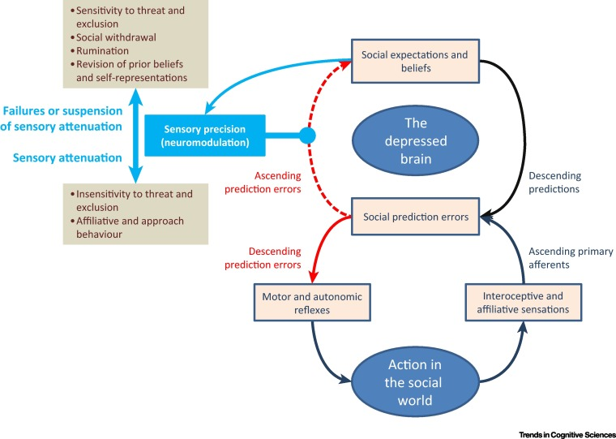

Figure 1. Key Figure: Schematic of the Depressed Brain

In active inference, action is mediated by motor and autonomic reflexes that are driven by descending (proprioceptive and interoceptive) prediction errors, such that reflexes resolve sensory prediction errors. Action is accompanied by the attenuation of (the precision of) ascending prediction errors. However, if prediction errors cannot be resolved through action this sensory attenuation is suspended, enabling ascending prediction errors to revise posterior beliefs and provide more appropriate top-down predictions. Under this model, adaptive states of depression entail an increase in the precision of (bottom-up) social (interoceptive and affiliative) prediction errors, which enables perceptual inference and learning about the causes of (aversive) social stimuli. This increase in precision heightens sensitivity (i.e., attention) to socioenvironmental cues while reducing confidence in (top-down) social predictions. Cognitively, this is reflected in the suspension of goal-directed behaviour (e.g., anhedonia), increased rumination about self–other relations, and an attentional bias toward aversive social cues. In pathological depression we suppose a persistent failure of sensory attenuation that induces aberrant prior beliefs about the probability of social rewards, producing negative expectations (e.g., pessimism, low self-worth). This failure can be pernicious and self-maintaining because it resolves uncertainty by soliciting sensory evidence that social rewards are unlikely and precluding exploratory behaviours with uncertain outcomes. In other words, both adaptive and aberrant depressed states reduce uncertainty in the social world by suppressing confident or acquisitive (reward–approach) behaviours and by generating signalling behaviours that seek reliable support (e.g., reassurance seeking) and defuse conflict (e.g., submissive behaviours).

Notably, the exacerbation of normative depressed states into severe, dysfunctional forms is also likely when depressive changes fail to alleviate social stress, creating a self-perpetuating cycle arising from heightened and prolonged arousal of ineffectual attempts to reduce socioenvironmental volatility [31]. This, in turn, can chronically activate neurophysiological stress responses and lead to debilitating sickness behaviours 13, 14. As discussed above, previous applications of the FEP suggest that this depressive spiral is engendered by a positive feedback loop between two neurocognitive mechanisms: the increased precision of social prediction errors, coupled with a negative bias affecting social predictions. Following active inference, this is likely to engender ongoing depressive behaviours that seek to confirm negative biases, creating a self-fulfilling prophecy (i.e., high predictability) born from mutually reinforcing patterns of cognition and behaviour [16]. Here, depressed can be interpreted as a maladaptive pattern of dysregulated defences: if this depressive response is effective, an individual either escapes or avoids the social stressor or adapts to it; if the defence fails, the individual is at risk of entering a self-perpetuating dysregulated state that falls beyond the normal range of adaptive functioning 31, 58. That said, it should also be recognised that clinical manifestations of depression can arise from asocial causes that produce neurobiological abnormalities typically associated with dysregulated mood (e.g., proinflammatory immune responses induced by physical illness [39]).

## The Depressed Brain

It is widely accepted that depression emerges from bidirectional interactions between hierarchically organised neural regions. Most of the theoretical work in this area concentrates on two general brain systems that work in concert: a ventral affective system including subcortical regions such as the amygdala and ventral striatum; and the prefrontal cortex (PFC), which modulates the reactions of the ventral affective system [1]. These systems comprise subcortical neural circuits responsible for the unconscious processing of affective and social stimuli on the one hand and, on the other hand, executive networks that regulate affective states, with medial prefrontal regions playing a particularly important role in modulating visceral and behavioural responses to adapt them to the external milieu 1, 59.

More particularly, evidence gleaned from neuroimaging and animal studies suggests that depression involves dysfunction of the ‘extended visceromotor network’, in which the medial PFC regulates affective states by modulating visceromotor output via connections with the amygdala, ventral striatum, hypothalamus, and other subcortical regions [60]. Brain regions across this network regulate motivation (e.g., anhedonia and dopaminergic function) and neurobiological responses to stress, and play a central role in social threat and reward processing 38, 40, 59, 61. Neurodevelopmental changes in these regions throughout adolescence are also thought to heighten vulnerability to disorder by increasing sensitivity to rapidly changing social contexts in this period (Box 4). Collectively, such findings fit well with our proposal that depression often stems from the need to adapt to complex social contexts, and manifests through the bidirectional interplay of hierarchical neuronal processes.

Box 4

The Adolescent Brain and Risk for Depression

The brain undergoes significant maturation in adolescence, involving processes that begin with puberty and continue until a young person is in their mid-to-late 20s [89]. Over this period there is a progressive increase in white matter alongside synaptic pruning and grey matter loss, which have the effect of delineating more clearly defined large-scale brain networks [90]. Subcortical regions, including the primary components of the reward system, undergo more rapid maturation [91], while the most prolonged development is in the **association cortex**, including prefrontal regions that are implicated in social processing 90, 92.

It is now widely accepted that the functional and structural changes that accompany adolescence reflect a particularly sensitive period for adapting to the social world. Brain imaging studies show that adolescence is typified by significant alterations in social and affective processing systems, which are thought to increase risk for mood disorder by heightening sensitivity to social threats in this period 40, 92, 93, 94. Coincident with these neurodevelopmental processes, there are also substantial changes in the adolescent social environment. Peer relationships become increasingly important, hierarchical, and complex and there is significant socioenvironmental volatility: friendships change frequently and romantic relationships are typically short lived [95].

It is unsurprising, then, that the period from adolescence to early adulthood is a peak time for the onset of depression [41]. During adolescence, sources of social uncertainty are frequently encountered, while the maturation of subcortical regions [91] and marked hormonal changes 94, 96 heighten sensitivity to affective and self-relevant social cues. Furthermore, although prefrontal cortical development leads to improved regulation of affective processes, it also increases sensitivity to the nuance and complexity of interpersonal relationships [62]. For this reason, increased vulnerability to depression starts in puberty but is maintained well beyond adolescence.

Specifically, we speculate that the extended visceromotor system responds to volatility in the social environment by increasing the precision of social prediction errors, initiating changes in neuronally encoded expectations that increase attention to social cues and motivate risk-averse behaviours (e.g., social withdrawal). This heightened sensitivity to somatic and affective cues leads, in turn, to further avoidance of interpersonal stressors. The depressive response is adaptive when changes in mood state and behaviour reduce uncertainty in the face of socioenvironmental change and lead to re-engagement with that environment when volatility abates (which should, at least in part, be brought about by depressive behaviours [31]). However, following the active inference literature, we suggest that the depressive response becomes maladaptive when there are (neuromodulatory) failures of ‘precision-engineered’ visceromotor inference – produced, for instance, by sustained social distress – leading to illness behaviours that fail to respond to improvements in interpersonal contexts and can often exacerbate socioenvironmental stress 13, 14. Neurodevelopmentally, the PFC can also potentiate vulnerability to depression by underwriting the formation of distal goals that, when frustrated by rejection or failure, can lead to depression by suppressing the brain’s reward system [62] and the confidence in (or precision of) our beliefs about behaviour [63], thereby inhibiting goal-directed behaviours.

Ultimately, our basic claim is that depression can be described as an adaptive faculty that underwrites emotional allostasis in an increasingly prosocial and volatile world. Physiologically, this faculty increases sensitivity to interpersonal, affiliative, and interoceptive cues. Clearly, sensitisation to stressful exteroceptive and interoceptive cues also has to be predicted by the hierarchical brain, which implicates the functional neuroanatomy described above. Under active inference, sensitivity to stress-related cues corresponds to their precision 13, 64, implicating neuromodulatory systems associated with reward, action selection, and interoceptive inference 65, 66, 67. Crucially, to act it is also necessary to attenuate the precision afforded to the sensory consequences of action (i.e., we have to ignore the fact that we are not currently acting). This means that an adaptive depressive response suspends sensory attenuation – and action – so that we can attend to interpersonal prediction errors and revise our (posterior) beliefs about our relationships with others, via perceptual inference and learning. Sensory attenuation can be regarded as the complement of sensory attention; that is, attenuating or augmenting the gain (precision) afforded to sensory prediction errors to ignore or select sensory information, respectively. From this perspective, maladaptive forms of depression reflect a pervasive, self-maintaining failure of sensory attenuation, leading to ruminations, false inference, and a concomitant inability to act and test these false beliefs.

Interestingly, exactly the same conclusions (namely, a failure of sensory attenuation) have been drawn for a range of neuropsychiatric disorders, from autism [68] to schizophrenia [69]. One could ask what is specific about this mechanism in depression and respond by referring to the particular (interoceptive and affiliative) modalities affected. However, perhaps the more intriguing implication is that the comorbidity of depression and other disorders might arise from a common pathophysiological mechanism that can be explained in terms of false inference.

## Concluding Remarks

In this Opinion article, we have endeavoured to contribute to the active inference literature on mood disorder by suggesting that normative levels of depressed mood instantiate an adaptive prior that minimises the likelihood of surprising interpersonal interactions when faced with threats of aversive social outcomes that typically compromised ancestral fitness. By extending beyond previous applications of the FEP to emphasise both the adaptive function of low mood and the causal role of the social ecology, we believe our model demonstrates the heuristic benefits of combining active inference with insights in psychology to improve our understanding of depressed mood and mood disorder. It also prompts new questions for research, calling for greater integration between neuroscientific and psychological approaches to explore the ways in which the neural mechanisms that underpin depression relate to behaviour, development, and the social world (see Outstanding Questions). In particular, the idea that depression can emerge from the need to navigate social risks stands to inform theory-driven approaches in computational psychiatry, which improve our understanding, prediction, and treatment of mental illness by using simulations and mathematical models to capture complex interactions across multiple causal levels 19, 70.

That said, we do not wish to imply that depression is solely attributable to social causes. In evolutionary psychology, for instance, the distinction between depressive states that occur in the context of specific social challenges and those that do not is widely recognised 29, 30. As we have noted, depression can also arise from depressogenic neurobiological abnormalities produced by influences other than unfavourable social conditions. Nevertheless, our model adds to the active inference literature by emphasising the importance of the social environment in explaining the aetiology and phenomenology of depression. It also underscores the potential utility of developing (computational) diagnostic tools that are capable of distinguishing between different aetiological pathways to clinical presentations of depression to inform treatment decisions.

In closing, our model also promotes clear avenues for intervention. To date, proponents of the FEP have advocated treatments that directly target dysregulated neural systems, such as psychopharmacological agents that act on the neurotransmitter systems that encode precision or uncertainty (e.g., serotonin, dopamine [16]). They have also recommended the use of cognitive behavioural therapies to disrupt the spiral of self-defeating actions typical of depression [16] or to construct new prediction signals that modify the gain on prediction errors via the salience network [14]. Our model adds to this work by emphasising the need to facilitate adaptive responses to social stress. This could explain the efficacy of interpersonal psychotherapy as a treatment for major depressive disorder [71] and highlights the value of prevention and early intervention efforts that reduce vulnerability by targeting modifiable risk factors in the social environment. Finally, simply having a positive and principled framework within which to understand depression – and the rationale for therapeutic interventions – is likely to be helpful for those seeking treatment. Our synthesis can be used to help clients understand why they have depression and to explain why, for example, it might be useful to combine interpersonal psychotherapy with antidepressants.

Outstanding Questions

How might the proposed link between depressed mood and an increase in the precision of social prediction errors be tested experimentally? Functional imaging and encephalography studies could be used to compare the neural responses of depressed versus non-depressed samples presented with unpredictable social stimuli.

What are the hierarchical neural mechanisms that underlie depressive responses to interpersonal surprise? What are the distinct functional roles of the neural regions associated with depression? How do patterns of effective connectivity between these minimise social prediction errors? Can segregated populations of representation and error units be identified that are dedicated to modelling the social world? How is the precision of social prediction errors differentially modulated by neurotransmitters like serotonin and dopamine?

How do genetic, epigenetic, and environmental influences shape the development of individual differences in the precision weighting of social prediction errors? Answering this question requires greater integration between predictive coding approaches and observational methodologies in psychology to explore the manifold ways in which developmental (particularly social) contexts influence brain development and bias perceptual inference.

Sex differences in susceptibility to depression are thought to be associated with hormonal changes and differential brain development in adolescence. To what extent are these changes associated with heightened sensitivity to socioenvironmental volatility?

Major depressive disorder is a heterogeneous condition born from various aetiologies. Which diagnostic tools might be used to reliably differentiate socially mediated depressive responses from other depressive outcomes to help inform targeted interventions?

## Acknowledgments

The authors thank Lucy Morrish, Jakob Hohwy, Alex Fornito, Rebecca Schwarzlose, and three anonymous reviewers for their valuable contributions. K.J.F. is funded by the Wellcome Trust and C.G.D. and S.W. are both funded by the National Health and Medical Research Council of Australia (NHMRC).

## References

**1**

J.H. Pfeifer, N.B. Allen

**Arrested development? Reconsidering dual-systems models of brain function in adolescence and disorders**

Trends Cogn. Sci., 16 (2012), pp. 322-329

[Article](https://www.sciencedirect.com/science/article/pii/S1364661312001040)[Download PDF](https://www.sciencedirect.com/science/article/pii/S1364661312001040/pdfft?md5=623731adbe5170bd5ba570c149aa7595&pid=1-s2.0-S1364661312001040-main.pdf)[View Record in Scopus](https://www.scopus.com/inward/record.url?eid=2-s2.0-84861693297&partnerID=10&rel=R3.0.0)[Google Scholar](https://scholar.google.com/scholar?q=Arrested%20development%20Reconsidering%20dual-systems%20models%20of%20brain%20function%20in%20adolescence%20and%20disorders)

**2**

J.H. Pfeifer, N.B. Allen

**The audacity of specificity: moving adolescent developmental neuroscience towards more powerful scientific paradigms and translatable models**

Dev. Cogn. Neurosci., 17 (2016), pp. 131-137

[Article](https://www.sciencedirect.com/science/article/pii/S1878929315001310)[Download PDF](https://www.sciencedirect.com/science/article/pii/S1878929315001310/pdfft?md5=8a0813e15a77765633dc27f3fcbcf1ee&pid=1-s2.0-S1878929315001310-main.pdf)[View Record in Scopus](https://www.scopus.com/inward/record.url?eid=2-s2.0-84955395902&partnerID=10&rel=R3.0.0)Google Scholar

**3**

P.B. Badcock

**Evolutionary systems theory: a unifying meta-theory of psychological science**

Rev. Gen. Psychol., 16 (2012), p. 10

[CrossRef](https://doi.org/10.1037/a0026381)[View Record in Scopus](https://www.scopus.com/inward/record.url?eid=2-s2.0-84867120811&partnerID=10&rel=R3.0.0)[Google Scholar](https://scholar.google.com/scholar_lookup?title=Evolutionary%20systems%20theory%3A%20a%20unifying%20meta-theory%20of%20psychological%20science&publication_year=2012&author=P.B.%20Badcock)

**4**

K. Friston

**The free-energy principle: a unified brain theory?**

Nat. Rev. Neurosci., 11 (2010), pp. 127-138

[CrossRef](https://doi.org/10.1038/nrn2787)[Google Scholar](https://scholar.google.com/scholar?q=The%20free-energy%20principle:%20a%20unified%20brain%20theory)

**5**

E. Tognoli, J.S. Kelso

**The metastable brain**

Neuron, 81 (2014), pp. 35-48

[Article](https://www.sciencedirect.com/science/article/pii/S0896627313011835)[Download PDF](https://www.sciencedirect.com/science/article/pii/S0896627313011835/pdfft?md5=26614bc30b6b73a5ff34169148fb1d4b&pid=1-s2.0-S0896627313011835-main.pdf)[View Record in Scopus](https://www.scopus.com/inward/record.url?eid=2-s2.0-84891761470&partnerID=10&rel=R3.0.0)[Google Scholar](https://scholar.google.com/scholar_lookup?title=The%20metastable%20brain&publication_year=2014&author=E.%20Tognoli&author=J.S.%20Kelso)

**6**

M.L. Anderson

**After Phrenology**

MIT Press (2014)

[Google Scholar](https://scholar.google.com/scholar_lookup?title=After%20Phrenology&publication_year=2014&author=M.L.%20Anderson)

**7**

A. Clark

**Surfing Uncertainty: Prediction, Action, and the Embodied Mind**

Oxford University Press (2015)

[Google Scholar](https://scholar.google.com/scholar_lookup?title=Surfing%20Uncertainty%3A%20Prediction%2C%20Action%2C%20and%20the%20Embodied%20Mind&publication_year=2015&author=A.%20Clark)

**8**

R. Lickliter, H. Honeycutt

**Developmental dynamics: toward a biologically plausible evolutionary psychology**

Psychol. Bull., 129 (2003), pp. 819-835

[View Record in Scopus](https://www.scopus.com/inward/record.url?eid=2-s2.0-0242406979&partnerID=10&rel=R3.0.0)Google Scholar

**9**

A. Clark

**Whatever next? Predictive brains, situated agents, and the future of cognitive science**

Behav. Brain Sci., 36 (2013), pp. 181-204

[CrossRef](https://doi.org/10.1017/s0140525x12000477)[View Record in Scopus](https://www.scopus.com/inward/record.url?eid=2-s2.0-84872566721&partnerID=10&rel=R3.0.0)[Google Scholar](https://scholar.google.com/scholar?q=Whatever%20next%20Predictive%20brains,%20situated%20agents,%20and%20the%20future%20of%20cognitive%20science)

**10**

A.M. Bastos, *et al.*

**Canonical microcircuits for predictive coding**

Neuron, 76 (2012), pp. 695-711

[Article](https://www.sciencedirect.com/science/article/pii/S0896627312009592)[Download PDF](https://www.sciencedirect.com/science/article/pii/S0896627312009592/pdfft?md5=08dd44365b478f285b391807cfa29bb8&pid=1-s2.0-S0896627312009592-main.pdf)[View Record in Scopus](https://www.scopus.com/inward/record.url?eid=2-s2.0-84869753419&partnerID=10&rel=R3.0.0)[Google Scholar](https://scholar.google.com/scholar_lookup?title=Canonical%20microcircuits%20for%20predictive%20coding&publication_year=2012&author=A.M.%20Bastos)

**11**

K.J. Friston, *et al.*

**Action and behavior: a free-energy formulation**

Biol. Cybern., 102 (2010), pp. 227-260

[CrossRef](https://doi.org/10.1007/s00422-010-0364-z)[View Record in Scopus](https://www.scopus.com/inward/record.url?eid=2-s2.0-77952091673&partnerID=10&rel=R3.0.0)[Google Scholar](https://scholar.google.com/scholar_lookup?title=Action%20and%20behavior%3A%20a%20free-energy%20formulation&publication_year=2010&author=K.J.%20Friston)

**12**

K. Friston

**Life as we know it**

J. R. Soc. Interface, 10 (2013), p. 20130475

[CrossRef](https://doi.org/10.1098/rsif.2013.0475)[Google Scholar](https://scholar.google.com/scholar_lookup?title=Life%20as%20we%20know%20it&publication_year=2013&author=K.%20Friston)

**13**

L.F. Barrett, W.K. Simmons

**Interoceptive predictions in the brain**

Nat. Rev. Neurosci., 16 (2015), pp. 419-429

[CrossRef](https://doi.org/10.1038/nrn3950)[View Record in Scopus](https://www.scopus.com/inward/record.url?eid=2-s2.0-84932193406&partnerID=10&rel=R3.0.0)[Google Scholar](https://scholar.google.com/scholar_lookup?title=Interoceptive%20predictions%20in%20the%20brain&publication_year=2015&author=L.F.%20Barrett&author=W.K.%20Simmons)

**14**

L.F. Barrett, *et al.*

**An active inference theory of allostasis and interoception in depression**

Philos. Trans. R. Soc. Lond. B Biol. Sci., 371 (2016), p. 20160011

[CrossRef](https://doi.org/10.1098/rstb.2016.0011)[View Record in Scopus](https://www.scopus.com/inward/record.url?eid=2-s2.0-84991457566&partnerID=10&rel=R3.0.0)[Google Scholar](https://scholar.google.com/scholar_lookup?title=An%20active%20inference%20theory%20of%20allostasis%20and%20interoception%20in%20depression&publication_year=2016&author=L.F.%20Barrett)

**15**

A.K. Seth, K.J. Friston

**Active interoceptive inference and the emotional brain**

Philos. Trans. R. Soc. Lond. B Biol. Sci., 371 (2016), p. 20160007

[CrossRef](https://doi.org/10.1098/rstb.2016.0007)[View Record in Scopus](https://www.scopus.com/inward/record.url?eid=2-s2.0-84991475039&partnerID=10&rel=R3.0.0)[Google Scholar](https://scholar.google.com/scholar_lookup?title=Active%20interoceptive%20inference%20and%20the%20emotional%20brain&publication_year=2016&author=A.K.%20Seth&author=K.J.%20Friston)

**16**

A.M. Chekroud

**Unifying treatments for depression: an application of the free energy principle**

Front. Psychol., 6 (2015), p. 153

[View Record in Scopus](https://www.scopus.com/inward/record.url?eid=2-s2.0-84926435274&partnerID=10&rel=R3.0.0)[Google Scholar](https://scholar.google.com/scholar_lookup?title=Unifying%20treatments%20for%20depression%3A%20an%20application%20of%20the%20free%20energy%20principle&publication_year=2015&author=A.M.%20Chekroud)

**17**

M. Joffily, G. Coricelli

**Emotional valence and the free-energy principle**

PLoS Comput. Biol., 9 (2013), p. e1003094

[CrossRef](https://doi.org/10.1371/journal.pcbi.1003094)[View Record in Scopus](https://www.scopus.com/inward/record.url?eid=2-s2.0-84879515315&partnerID=10&rel=R3.0.0)[Google Scholar](https://scholar.google.com/scholar_lookup?title=Emotional%20valence%20and%20the%20free-energy%20principle&publication_year=2013&author=M.%20Joffily&author=G.%20Coricelli)

**18**

M. Moutoussis, *et al.*

**Bayesian inferences about the self (and others): a review**

Conscious. Cogn., 25 (2014), pp. 67-76

[Article](https://www.sciencedirect.com/science/article/pii/S1053810014000105)[Download PDF](https://www.sciencedirect.com/science/article/pii/S1053810014000105/pdfft?md5=5bea62c7e6245066c00eec6bc0d3013c&pid=1-s2.0-S1053810014000105-main.pdf)[View Record in Scopus](https://www.scopus.com/inward/record.url?eid=2-s2.0-84894496868&partnerID=10&rel=R3.0.0)[Google Scholar](https://scholar.google.com/scholar?q=Bayesian%20inferences%20about%20the%20self%20:%20a%20review)

**19**

R.A. Adams, *et al.*

**Computational psychiatry: towards a mathematically informed understanding of mental illness**

J. Neurol. Neurosurg. Psychiatry, 87 (2016), pp. 53-63

[Google Scholar](https://scholar.google.com/scholar_lookup?title=Computational%20psychiatry%3A%20towards%20a%20mathematically%20informed%20understanding%20of%20mental%20illness&publication_year=2016&author=R.A.%20Adams)

**20**

D. Nettle, M. Bateson

**The evolutionary origins of mood and its disorders**

Curr. Biol., 22 (2012), pp. R712-R721

[Article](https://www.sciencedirect.com/science/article/pii/S0960982212006653)[Download PDF](https://www.sciencedirect.com/science/article/pii/S0960982212006653/pdfft?md5=ed3e88ba151dcb891e10d6952272bc7a&pid=1-s2.0-S0960982212006653-main.pdf)[View Record in Scopus](https://www.scopus.com/inward/record.url?eid=2-s2.0-84866164605&partnerID=10&rel=R3.0.0)[Google Scholar](https://scholar.google.com/scholar_lookup?title=The%20evolutionary%20origins%20of%20mood%20and%20its%20disorders&publication_year=2012&author=D.%20Nettle&author=M.%20Bateson)

**21**

L.R. Caporael

**Evolutionary psychology: toward a unifying theory and a hybrid science**

Annu. Rev. Psychol., 52 (2001), pp. 607-628

[View Record in Scopus](https://www.scopus.com/inward/record.url?eid=2-s2.0-0035234390&partnerID=10&rel=R3.0.0)[Google Scholar](https://scholar.google.com/scholar_lookup?title=Evolutionary%20psychology%3A%20toward%20a%20unifying%20theory%20and%20a%20hybrid%20science&publication_year=2001&author=L.R.%20Caporael)

**22**

D.C. Geary, D.F. Bjorklund

**Evolutionary developmental psychology**

Child Dev., 71 (2000), pp. 57-65

[View Record in Scopus](https://www.scopus.com/inward/record.url?eid=2-s2.0-0033657163&partnerID=10&rel=R3.0.0)[Google Scholar](https://scholar.google.com/scholar_lookup?title=Evolutionary%20developmental%20psychology&publication_year=2000&author=D.C.%20Geary&author=D.F.%20Bjorklund)

**23**

D.T. Kenrick, *et al.*

**Dynamical evolutionary psychology: mapping the domains of the new interactionist paradigm**

Pers. Soc. Psychol. Rev., 6 (2002), pp. 347-356

[View Record in Scopus](https://www.scopus.com/inward/record.url?eid=2-s2.0-0036440857&partnerID=10&rel=R3.0.0)[Google Scholar](https://scholar.google.com/scholar_lookup?title=Dynamical%20evolutionary%20psychology%3A%20mapping%20the%20domains%20of%20the%20new%20interactionist%20paradigm&publication_year=2002&author=D.T.%20Kenrick)

**24**

A. Ploeger, *et al.*

**Is evolutionary psychology a metatheory for psychology? A discussion of four major issues in psychology from an evolutionary developmental perspective**

Psychol. Inq., 19 (2008), pp. 1-18

[CrossRef](https://doi.org/10.1080/10478400701774006)[View Record in Scopus](https://www.scopus.com/inward/record.url?eid=2-s2.0-41149120067&partnerID=10&rel=R3.0.0)Google Scholar

**25**

W.E. Frankenhuis

**Bridging developmental systems theory and evolutionary psychology using dynamic optimization**

Dev. Sci., 16 (2013), pp. 584-598

[CrossRef](https://doi.org/10.1111/desc.12053)[View Record in Scopus](https://www.scopus.com/inward/record.url?eid=2-s2.0-84879550093&partnerID=10&rel=R3.0.0)[Google Scholar](https://scholar.google.com/scholar_lookup?title=Bridging%20developmental%20systems%20theory%20and%20evolutionary%20psychology%20using%20dynamic%20optimization&publication_year=2013&author=W.E.%20Frankenhuis)

**26**

N. Tinbergen

**On aims and methods of ethology**

Z. Tierpsychol., 20 (1963), pp. 410-433

[Google Scholar](https://scholar.google.com/scholar_lookup?title=On%20aims%20and%20methods%20of%20ethology&publication_year=1963&author=N.%20Tinbergen)

**27**

P.J. Marshall

**Coping with complexity: developmental systems and multilevel analyses in developmental psychopathology**

Dev. Psychopathol., 25 (2013), pp. 1311-1324

[View Record in Scopus](https://www.scopus.com/inward/record.url?eid=2-s2.0-84891416921&partnerID=10&rel=R3.0.0)Google Scholar

**28**

N.B. Allen, P.B. Badcock

**Darwinian models of depression: a review of evolutionary accounts of mood and mood disorders**

Prog. Neuropsychopharmacol. Biol. Psychiatry, 30 (2006), pp. 815-826

[Article](https://www.sciencedirect.com/science/article/pii/S027858460600008X)[Download PDF](https://www.sciencedirect.com/science/article/pii/S027858460600008X/pdfft?md5=4cf13815d8b00990176124a55b67ff78&pid=1-s2.0-S027858460600008X-main.pdf)[View Record in Scopus](https://www.scopus.com/inward/record.url?eid=2-s2.0-33747052057&partnerID=10&rel=R3.0.0)Google Scholar

**29**

Z. Durisko, *et al.*

**An adaptationist perspective on the etiology of depression**

J. Affect. Disord., 172 (2015), pp. 315-323

[Article](https://www.sciencedirect.com/science/article/pii/S0165032714005862)[Download PDF](https://www.sciencedirect.com/science/article/pii/S0165032714005862/pdfft?md5=837dc60ae106660a3e1b577b5948dc9c&pid=1-s2.0-S0165032714005862-main.pdf)[View Record in Scopus](https://www.scopus.com/inward/record.url?eid=2-s2.0-84908432721&partnerID=10&rel=R3.0.0)[Google Scholar](https://scholar.google.com/scholar_lookup?title=An%20adaptationist%20perspective%20on%20the%20etiology%20of%20depression&publication_year=2015&author=Z.%20Durisko)

**30**

P. Gilbert

**Evolution and depression: issues and implications**

Psychol. Med., 36 (2006), pp. 287-297

[CrossRef](https://doi.org/10.1017/s0033291705006112)[View Record in Scopus](https://www.scopus.com/inward/record.url?eid=2-s2.0-33646703309&partnerID=10&rel=R3.0.0)[Google Scholar](https://scholar.google.com/scholar_lookup?title=Evolution%20and%20depression%3A%20issues%20and%20implications&publication_year=2006&author=P.%20Gilbert)

**31**

N.B. Allen, P.B. Badcock

**The social risk hypothesis of depressed mood: evolutionary, psychosocial, and neurobiological perspectives**

Psychol. Bull., 129 (2003), pp. 887-913

[View Record in Scopus](https://www.scopus.com/inward/record.url?eid=2-s2.0-0242658705&partnerID=10&rel=R3.0.0)Google Scholar

**32**

V. Vialou, *et al.*

**Epigenetic mechanisms of depression and antidepressants action**

Annu. Rev. Pharmacol. Toxicol., 53 (2013), pp. 59-87

[CrossRef](https://doi.org/10.1146/annurev-pharmtox-010611-134540)[View Record in Scopus](https://www.scopus.com/inward/record.url?eid=2-s2.0-84872241553&partnerID=10&rel=R3.0.0)[Google Scholar](https://scholar.google.com/scholar_lookup?title=Epigenetic%20mechanisms%20of%20depression%20and%20antidepressants%20action&publication_year=2013&author=V.%20Vialou)

**33**

M.M. Weissman, *et al.*

**Families at high and low risk for depression: a 3-generation study**

Arch. Gen. Psychiatry, 62 (2005), pp. 29-36

[CrossRef](https://doi.org/10.1001/archpsyc.62.1.29)[View Record in Scopus](https://www.scopus.com/inward/record.url?eid=2-s2.0-11844298940&partnerID=10&rel=R3.0.0)[Google Scholar](https://scholar.google.com/scholar_lookup?title=Families%20at%20high%20and%20low%20risk%20for%20depression%3A%20a%203-generation%20study&publication_year=2005&author=M.M.%20Weissman)

**34**

H. Sun, *et al.*

**Epigenetics of the depressed brain: role of histone acetylation and methylation**

Neuropsychopharmacology, 38 (2013), pp. 124-137

[CrossRef](https://doi.org/10.1038/npp.2012.73)[View Record in Scopus](https://www.scopus.com/inward/record.url?eid=2-s2.0-84869096094&partnerID=10&rel=R3.0.0)[Google Scholar](https://scholar.google.com/scholar_lookup?title=Epigenetics%20of%20the%20depressed%20brain%3A%20role%20of%20histone%20acetylation%20and%20methylation&publication_year=2013&author=H.%20Sun)

**35**

M.J. Meaney

**Maternal care, gene expression, and the transmission of individual differences in stress reactivity across generations**

Annu. Rev. Neurosci., 24 (2001), pp. 1161-1192

[CrossRef](https://doi.org/10.1146/annurev.neuro.24.1.1161)[View Record in Scopus](https://www.scopus.com/inward/record.url?eid=2-s2.0-0034928759&partnerID=10&rel=R3.0.0)Google Scholar

**36**

C. Heim, E.B. Binder

**Current research trends in early life stress and depression: review of human studies on sensitive periods, gene–environment interactions, and epigenetics**

Exp. Neurol., 233 (2012), pp. 102-111

[Article](https://www.sciencedirect.com/science/article/pii/S0014488611004043)[Download PDF](https://www.sciencedirect.com/science/article/pii/S0014488611004043/pdfft?md5=23ddc2c727eafd4bf81b0d5d74ddff79&pid=1-s2.0-S0014488611004043-main.pdf)[View Record in Scopus](https://www.scopus.com/inward/record.url?eid=2-s2.0-84856181467&partnerID=10&rel=R3.0.0)Google Scholar

**37**

P. Gold

**The organization of the stress system and its dysregulation in depressive illness**

Mol. Psychiatry, 20 (2015), pp. 32-47

[CrossRef](https://doi.org/10.1038/mp.2014.163)[View Record in Scopus](https://www.scopus.com/inward/record.url?eid=2-s2.0-84922259218&partnerID=10&rel=R3.0.0)[Google Scholar](https://scholar.google.com/scholar_lookup?title=The%20organization%20of%20the%20stress%20system%20and%20its%20dysregulation%20in%20depressive%20illness&publication_year=2015&author=P.%20Gold)

**38**

R. De Raedt, E.H. Koster

**Understanding vulnerability for depression from a cognitive neuroscience perspective: a reappraisal of attentional factors and a new conceptual framework**

Cogn. Affect. Behav. Neurosci., 10 (2010), pp. 50-70

[View Record in Scopus](https://www.scopus.com/inward/record.url?eid=2-s2.0-77953105171&partnerID=10&rel=R3.0.0)Google Scholar

**39**

G.M. Slavich, M.R. Irwin

**From stress to inflammation and major depressive disorder: a social signal transduction theory of depression**

Psychol. Bull., 140 (2014), p. 774

[CrossRef](https://doi.org/10.1037/a0035302)[View Record in Scopus](https://www.scopus.com/inward/record.url?eid=2-s2.0-84922642868&partnerID=10&rel=R3.0.0)Google Scholar

**40**

J.S. Silk, *et al.*

**Why do anxious children become depressed teenagers? The role of social evaluative threat and reward processing**

Psychol. Med., 42 (2012), pp. 2095-2107

[View Record in Scopus](https://www.scopus.com/inward/record.url?eid=2-s2.0-84871518448&partnerID=10&rel=R3.0.0)[Google Scholar](https://scholar.google.com/scholar?q=Why%20do%20anxious%20children%20become%20depressed%20teenagers%20The%20role%20of%20social%20evaluative%20threat%20and%20reward%20processing)

**41**

S.L. Andersen, M.H. Teicher

**Stress, sensitive periods and maturational events in adolescent depression**

Trends Neurosci., 31 (2008), pp. 183-191

[Article](https://www.sciencedirect.com/science/article/pii/S0166223608000660)[Download PDF](https://www.sciencedirect.com/science/article/pii/S0166223608000660/pdfft?md5=e7e42f74856c5a376914d647262b7fa8&pid=1-s2.0-S0166223608000660-main.pdf)[View Record in Scopus](https://www.scopus.com/inward/record.url?eid=2-s2.0-41249084517&partnerID=10&rel=R3.0.0)[Google Scholar](https://scholar.google.com/scholar_lookup?title=Stress%2C%20sensitive%20periods%20and%20maturational%20events%20in%20adolescent%20depression&publication_year=2008&author=S.L.%20Andersen&author=M.H.%20Teicher)

**42**

I.H. Gotlib, C. Hammen

**Handbook of Depression**

(3rd edn), Guilford Press (2014)

[Google Scholar](https://scholar.google.com/scholar_lookup?title=Handbook%20of%20Depression&publication_year=2014&author=I.H.%20Gotlib&author=C.%20Hammen)

**43**

S. Vrshek-Schallhorn, *et al.*

**Refining the candidate environment interpersonal stress, the serotonin transporter polymorphism, and gene–environment interactions in major depression**

Clin. Psychol. Sci., 2 (2014), pp. 235-248

[CrossRef](https://doi.org/10.1177/2167702613499329)[View Record in Scopus](https://www.scopus.com/inward/record.url?eid=2-s2.0-84901260565&partnerID=10&rel=R3.0.0)Google Scholar

**44**

S. Cohen, T.A. Wills

**Stress, social support, and the buffering hypothesis**

Psychol. Bull., 98 (1985), pp. 310-357

[View Record in Scopus](https://www.scopus.com/inward/record.url?eid=2-s2.0-0022115624&partnerID=10&rel=R3.0.0)[Google Scholar](https://scholar.google.com/scholar_lookup?title=Stress%2C%20social%20support%2C%20and%20the%20buffering%20hypothesis&publication_year=1985&author=S.%20Cohen&author=T.A.%20Wills)

**45**

L.C. Hawkley, J.P. Capitanio

**Perceived social isolation, evolutionary fitness and health outcomes: a lifespan approach**

Philos. Trans. R. Soc. Lond. B Biol. Sci., 370 (2015), p. 20140114

[CrossRef](https://doi.org/10.1098/rstb.2014.0114)Google Scholar

**46**

J.M. Leppänen

**Emotional information processing in mood disorders: a review of behavioral and neuroimaging findings**

Curr. Opin. Psychiatry, 19 (2006), pp. 34-39

[CrossRef](https://doi.org/10.1097/01.yco.0000191500.46411.00)[View Record in Scopus](https://www.scopus.com/inward/record.url?eid=2-s2.0-33646836275&partnerID=10&rel=R3.0.0)Google Scholar

**47**

B.L. Hankin, *et al.*

**Corumination, interpersonal stress generation, and internalizing symptoms: accumulating effects and transactional influences in a multiwave study of adolescents**

Dev. Psychopathol., 22 (2010), pp. 217-235

[View Record in Scopus](https://www.scopus.com/inward/record.url?eid=2-s2.0-77950927346&partnerID=10&rel=R3.0.0)Google Scholar

**48**

M.T. Moore, D.M. Fresco

**Depressive realism: a meta-analytic review**

Clin. Psychol. Rev., 32 (2012), pp. 496-509

[Article](https://www.sciencedirect.com/science/article/pii/S0272735812000670)[Download PDF](https://www.sciencedirect.com/science/article/pii/S0272735812000670/pdfft?md5=97b12df19fc13623b8c1179fca788a27&pid=1-s2.0-S0272735812000670-main.pdf)[Google Scholar](https://scholar.google.com/scholar_lookup?title=Depressive%20realism%3A%20a%20meta-analytic%20review&publication_year=2012&author=M.T.%20Moore&author=D.M.%20Fresco)

**49**

J.P. Forgas

**Can sadness be good for you?**

Aust. Psychol., 52 (2017), pp. 3-13

[CrossRef](https://doi.org/10.1111/ap.12232)[View Record in Scopus](https://www.scopus.com/inward/record.url?eid=2-s2.0-85009216519&partnerID=10&rel=R3.0.0)[Google Scholar](https://scholar.google.com/scholar?q=Can%20sadness%20be%20good%20for%20you)

**50**

D.A. Pizzagalli

**Depression, stress, and anhedonia: toward a synthesis and integrated model**

Annu. Rev. Clin. Psychol., 10 (2014), p. 393

[CrossRef](https://doi.org/10.1146/annurev-clinpsy-050212-185606)[View Record in Scopus](https://www.scopus.com/inward/record.url?eid=2-s2.0-84897114163&partnerID=10&rel=R3.0.0)[Google Scholar](https://scholar.google.com/scholar_lookup?title=Depression%2C%20stress%2C%20and%20anhedonia%3A%20toward%20a%20synthesis%20and%20integrated%20model&publication_year=2014&author=D.A.%20Pizzagalli)

**51**

E.H. Hagen

**Evolutionary theories of depression: a critical review**

Can. J. Psychiatry, 56 (2011), pp. 716-726

[CrossRef](https://doi.org/10.1177/070674371105601203)[View Record in Scopus](https://www.scopus.com/inward/record.url?eid=2-s2.0-84255200427&partnerID=10&rel=R3.0.0)[Google Scholar](https://scholar.google.com/scholar_lookup?title=Evolutionary%20theories%20of%20depression%3A%20a%20critical%20review&publication_year=2011&author=E.H.%20Hagen)

**52**

J.L. Hames, *et al.*

**Interpersonal processes in depression**

Annu. Rev. Clin. Psychol., 9 (2013), pp. 355-377

[CrossRef](https://doi.org/10.1146/annurev-clinpsy-050212-185553)[View Record in Scopus](https://www.scopus.com/inward/record.url?eid=2-s2.0-84875911931&partnerID=10&rel=R3.0.0)[Google Scholar](https://scholar.google.com/scholar_lookup?title=Interpersonal%20processes%20in%20depression&publication_year=2013&author=J.L.%20Hames)

**53**

L. Sloman, P. Gilbert

**Subordination and Defeat: An Evolutionary approach to Mood Disorders and Their Therapy**

Routledge (2000)

Google Scholar

**54**

P. Badcock, N. Allen

**Adaptive social reasoning in depressed mood and depressive vulnerability**

Cogn. Emot., 17 (2003), pp. 647-670

[View Record in Scopus](https://www.scopus.com/inward/record.url?eid=2-s2.0-0037593602&partnerID=10&rel=R3.0.0)[Google Scholar](https://scholar.google.com/scholar_lookup?title=Adaptive%20social%20reasoning%20in%20depressed%20mood%20and%20depressive%20vulnerability&publication_year=2003&author=P.%20Badcock&author=N.%20Allen)

**55**

P.B. Badcock, N.B. Allen

**Evolution, social cognition, and depressed mood: exploring the relationship between depressed mood and social risk taking**

J.P. Forgas, *et al.* (Eds.), Evolution and the Social Mind: Evolutionary Psychology and Social Cognition, Psychology Press (2007), pp. 125-142

Google Scholar

**56**

J.C. Dunn, *et al.*

**Retreating to safety: testing the social risk hypothesis model of depression**

Evol. Hum. Behav., 33 (2012), pp. 746-758

[Article](https://www.sciencedirect.com/science/article/pii/S1090513812000633)[Download PDF](https://www.sciencedirect.com/science/article/pii/S1090513812000633/pdfft?md5=ea8b5d986d96d2932a92177b1e7e376b&pid=1-s2.0-S1090513812000633-main.pdf)[View Record in Scopus](https://www.scopus.com/inward/record.url?eid=2-s2.0-84867900355&partnerID=10&rel=R3.0.0)[Google Scholar](https://scholar.google.com/scholar_lookup?title=Retreating%20to%20safety%3A%20testing%20the%20social%20risk%20hypothesis%20model%20of%20depression&publication_year=2012&author=J.C.%20Dunn)

**57**

J.M. Girard, *et al.*

**Social risk and depression: evidence from manual and automatic facial expression analysis**

Proc. Int. Conf. Autom. Face Gesture Recognit., 2013 (2013), pp. 1-8

[CrossRef](https://doi.org/10.1109/FG.2013.6553748)[Google Scholar](https://scholar.google.com/scholar_lookup?title=Social%20risk%20and%20depression%3A%20evidence%20from%20manual%20and%20automatic%20facial%20expression%20analysis&publication_year=2013&author=J.M.%20Girard)

**58**

P. Gilbert

**Depression and stress: a biopsychosocial exploration of evolved functions and mechanisms**

Stress, 4 (2001), pp. 121-135

[CrossRef](https://doi.org/10.3109/10253890109115726)[View Record in Scopus](https://www.scopus.com/inward/record.url?eid=2-s2.0-0034814045&partnerID=10&rel=R3.0.0)[Google Scholar](https://scholar.google.com/scholar_lookup?title=Depression%20and%20stress%3A%20a%20biopsychosocial%20exploration%20of%20evolved%20functions%20and%20mechanisms&publication_year=2001&author=P.%20Gilbert)

**59**

A. Kupferberg, *et al.*

**Social functioning in major depressive disorder**

Neurosci. Biobehav. Rev., 69 (2016), pp. 313-332

[Article](https://www.sciencedirect.com/science/article/pii/S0149763415302487)[Download PDF](https://www.sciencedirect.com/science/article/pii/S0149763415302487/pdfft?md5=a85ba4d366d5abbf8f1e2181069c491d&pid=1-s2.0-S0149763415302487-main.pdf)[View Record in Scopus](https://www.scopus.com/inward/record.url?eid=2-s2.0-84983032349&partnerID=10&rel=R3.0.0)[Google Scholar](https://scholar.google.com/scholar_lookup?title=Social%20functioning%20in%20major%20depressive%20disorder&publication_year=2016&author=A.%20Kupferberg)

**60**

J.L. Price, W.C. Drevets

**Neural circuits underlying the pathophysiology of mood disorders**

Trends Cogn. Sci., 16 (2012), pp. 61-71

[Article](https://www.sciencedirect.com/science/article/pii/S1364661311002622)[Download PDF](https://www.sciencedirect.com/science/article/pii/S1364661311002622/pdfft?md5=ec1a5fc07ede36e8b7c8e02b1bc27816&pid=1-s2.0-S1364661311002622-main.pdf)[View Record in Scopus](https://www.scopus.com/inward/record.url?eid=2-s2.0-84855312099&partnerID=10&rel=R3.0.0)[Google Scholar](https://scholar.google.com/scholar_lookup?title=Neural%20circuits%20underlying%20the%20pathophysiology%20of%20mood%20disorders&publication_year=2012&author=J.L.%20Price&author=W.C.%20Drevets)

**61**

M.F. Rushworth, *et al.*

**Are there specialized circuits for social cognition and are they unique to humans?**

Curr. Opin. Neurobiol., 23 (2013), pp. 436-442

[Article](https://www.sciencedirect.com/science/article/pii/S0959438812001870)[Download PDF](https://www.sciencedirect.com/science/article/pii/S0959438812001870/pdfft?md5=4c5e1c9e3aed112d44d56921a5083814&pid=1-s2.0-S0959438812001870-main.pdf)[View Record in Scopus](https://www.scopus.com/inward/record.url?eid=2-s2.0-84878375187&partnerID=10&rel=R3.0.0)[Google Scholar](https://scholar.google.com/scholar?q=Are%20there%20specialized%20circuits%20for%20social%20cognition%20and%20are%20they%20unique%20to%20humans)

**62**

C.G. Davey, *et al.*

**The emergence of depression in adolescence: development of the prefrontal cortex and the representation of reward**

Neurosci. Biobehav. Rev., 32 (2008), pp. 1-19

[Article](https://www.sciencedirect.com/science/article/pii/S014976340700053X)[Download PDF](https://www.sciencedirect.com/science/article/pii/S014976340700053X/pdfft?md5=e15b30a4354e1010eab64b89ff317490&pid=1-s2.0-S014976340700053X-main.pdf)[View Record in Scopus](https://www.scopus.com/inward/record.url?eid=2-s2.0-36348987683&partnerID=10&rel=R3.0.0)Google Scholar

**63**

K. Friston, *et al.*

**Active inference and epistemic value**

Cogn. Neurosci., 6 (2015), pp. 187-214

[CrossRef](https://doi.org/10.1080/17588928.2015.1020053)[View Record in Scopus](https://www.scopus.com/inward/record.url?eid=2-s2.0-84954371516&partnerID=10&rel=R3.0.0)[Google Scholar](https://scholar.google.com/scholar_lookup?title=Active%20inference%20and%20epistemic%20value&publication_year=2015&author=K.%20Friston)

**64**

K. Friston, *et al.*

**The anatomy of choice: dopamine and decision-making**

Philos. Trans. R. Soc. Lond. B Biol. Sci., 369 (2014), p. 20130481

[CrossRef](https://doi.org/10.1098/rstb.2013.0481)[Google Scholar](https://scholar.google.com/scholar_lookup?title=The%20anatomy%20of%20choice%3A%20dopamine%20and%20decision-making&publication_year=2014&author=K.%20Friston)

**65**

M.P. Paulus, M.B. Stein

**An insular view of anxiety**

Biol. Psychiatry, 60 (2006), pp. 383-387

[Article](https://www.sciencedirect.com/science/article/pii/S0006322306004768)[Download PDF](https://www.sciencedirect.com/science/article/pii/S0006322306004768/pdfft?md5=cca0a2bc77f5c9ff411a94c38f0c6c91&pid=1-s2.0-S0006322306004768-main.pdf)[View Record in Scopus](https://www.scopus.com/inward/record.url?eid=2-s2.0-33747040807&partnerID=10&rel=R3.0.0)[Google Scholar](https://scholar.google.com/scholar_lookup?title=An%20insular%20view%20of%20anxiety&publication_year=2006&author=M.P.%20Paulus&author=M.B.%20Stein)

**66**

G. Pezzulo, *et al.*

**Active inference, homeostatic regulation and adaptive behavioural control**

Prog. Neurobiol., 134 (2015), pp. 17-35

[Article](https://www.sciencedirect.com/science/article/pii/S0301008215000908)[Download PDF](https://www.sciencedirect.com/science/article/pii/S0301008215000908/pdfft?md5=55e49f8a6d5ee49fd384beb53669e574&pid=1-s2.0-S0301008215000908-main.pdf)[Google Scholar](https://scholar.google.com/scholar_lookup?title=Active%20inference%2C%20homeostatic%20regulation%20and%20adaptive%20behavioural%20control&publication_year=2015&author=G.%20Pezzulo)

**67**

M. Waselus, *et al.*

**Collateralized dorsal raphe nucleus projections: a mechanism for the integration of diverse functions during stress**

J. Chem. Neuroanat., 41 (2011), pp. 266-280

[Article](https://www.sciencedirect.com/science/article/pii/S0891061811000470)[Download PDF](https://www.sciencedirect.com/science/article/pii/S0891061811000470/pdfft?md5=c4407eb99b780e3f9b49a49fb6f828ce&pid=1-s2.0-S0891061811000470-main.pdf)[View Record in Scopus](https://www.scopus.com/inward/record.url?eid=2-s2.0-79960083903&partnerID=10&rel=R3.0.0)Google Scholar

**68**

E. Pellicano, D. Burr

**When the world becomes ‘too real’: a Bayesian explanation of autistic perception**

Trends Cogn. Sci., 16 (2012), pp. 504-510

[Article](https://www.sciencedirect.com/science/article/pii/S1364661312002008)[Download PDF](https://www.sciencedirect.com/science/article/pii/S1364661312002008/pdfft?md5=eba019f1bc082349a6e1523a1b24700c&pid=1-s2.0-S1364661312002008-main.pdf)[View Record in Scopus](https://www.scopus.com/inward/record.url?eid=2-s2.0-84866562603&partnerID=10&rel=R3.0.0)[Google Scholar](https://scholar.google.com/scholar?q=When%20the%20world%20becomes%20too%20real:%20a%20Bayesian%20explanation%20of%20autistic%20perception)

**69**

P.C. Fletcher, C.D. Frith

**Perceiving is believing: a Bayesian approach to explaining the positive symptoms of schizophrenia**

Nat. Rev. Neurosci., 10 (2009), pp. 48-58

[CrossRef](https://doi.org/10.1038/nrn2536)Google Scholar

**70**

K.J. Friston, *et al.*

**Computational psychiatry: the brain as a phantastic organ**

Lancet Psychiatry, 1 (2014), pp. 148-158

[Article](https://www.sciencedirect.com/science/article/pii/S2215036614702755)[Download PDF](https://www.sciencedirect.com/science/article/pii/S2215036614702755/pdfft?md5=af7b4c49ffb748bd2624dd5aeda38432&pid=1-s2.0-S2215036614702755-main.pdf)[View Record in Scopus](https://www.scopus.com/inward/record.url?eid=2-s2.0-84912097624&partnerID=10&rel=R3.0.0)[Google Scholar](https://scholar.google.com/scholar_lookup?title=Computational%20psychiatry%3A%20the%20brain%20as%20a%20phantastic%20organ&publication_year=2014&author=K.J.%20Friston)

**71**

P. Cuijpers, *et al.*

**Interpersonal psychotherapy for depression: a meta-analysis**

Am. J. Psychiatry, 168 (2011), pp. 581-592

[CrossRef](https://doi.org/10.1176/appi.ajp.2010.10101411)[View Record in Scopus](https://www.scopus.com/inward/record.url?eid=2-s2.0-79960294601&partnerID=10&rel=R3.0.0)[Google Scholar](https://scholar.google.com/scholar_lookup?title=Interpersonal%20psychotherapy%20for%20depression%3A%20a%20meta-analysis&publication_year=2011&author=P.%20Cuijpers)

**72**

G. Wiest

**Neural and mental hierarchies**

Front. Psychol., 3 (2012), p. 516

[Google Scholar](https://scholar.google.com/scholar_lookup?title=Neural%20and%20mental%20hierarchies&publication_year=2012&author=G.%20Wiest)

**73**

H.-J. Park, K. Friston

**Structural and functional brain networks: from connections to cognition**

Science, 342 (2013), p. 1238411

[View Record in Scopus](https://www.scopus.com/inward/record.url?eid=2-s2.0-84887291519&partnerID=10&rel=R3.0.0)[Google Scholar](https://scholar.google.com/scholar_lookup?title=Structural%20and%20functional%20brain%20networks%3A%20from%20connections%20to%20cognition&publication_year=2013&author=H.-J.%20Park&author=K.%20Friston)

**74**

J. Hohwy

**The Predictive Mind**

Oxford University Press (2013)

[Google Scholar](https://scholar.google.com/scholar_lookup?title=The%20Predictive%20Mind&publication_year=2013&author=J.%20Hohwy)

**75**

O. Sporns, R.F. Betzel

**Modular brain networks**

Annu. Rev. Psychol., 67 (2016), pp. 613-640

[CrossRef](https://doi.org/10.1146/annurev-psych-122414-033634)[View Record in Scopus](https://www.scopus.com/inward/record.url?eid=2-s2.0-84945169807&partnerID=10&rel=R3.0.0)[Google Scholar](https://scholar.google.com/scholar_lookup?title=Modular%20brain%20networks&publication_year=2016&author=O.%20Sporns&author=R.F.%20Betzel)

**76**

M. Kaiser, *et al.*

**Hierarchy and dynamics of neural networks**

Front. Neuroinformatics, 4 (2010), p. 112

[View Record in Scopus](https://www.scopus.com/inward/record.url?eid=2-s2.0-82955191453&partnerID=10&rel=R3.0.0)[Google Scholar](https://scholar.google.com/scholar_lookup?title=Hierarchy%20and%20dynamics%20of%20neural%20networks&publication_year=2010&author=M.%20Kaiser)

**77**

R.L. Buckner, F.M. Krienen

**The evolution of distributed association networks in the human brain**

Trends Cogn. Sci., 17 (2013), pp. 648-665

[Article](https://www.sciencedirect.com/science/article/pii/S1364661313002210)[Download PDF](https://www.sciencedirect.com/science/article/pii/S1364661313002210/pdfft?md5=87edf50cc9fc460271c4461d85984c72&pid=1-s2.0-S1364661313002210-mainext.pdf)[View Record in Scopus](https://www.scopus.com/inward/record.url?eid=2-s2.0-84888872635&partnerID=10&rel=R3.0.0)[Google Scholar](https://scholar.google.com/scholar_lookup?title=The%20evolution%20of%20distributed%20association%20networks%20in%20the%20human%20brain&publication_year=2013&author=R.L.%20Buckner&author=F.M.%20Krienen)

**78**

B.L. Finlay, R. Uchiyama

**Developmental mechanisms channeling cortical evolution**

Trends Neurosci., 38 (2015), pp. 69-76

[Article](https://www.sciencedirect.com/science/article/pii/S0166223614002124)[Download PDF](https://www.sciencedirect.com/science/article/pii/S0166223614002124/pdfft?md5=e6c42c655928616070cc757fb6c949fd&pid=1-s2.0-S0166223614002124-main.pdf)[View Record in Scopus](https://www.scopus.com/inward/record.url?eid=2-s2.0-84922938910&partnerID=10&rel=R3.0.0)[Google Scholar](https://scholar.google.com/scholar_lookup?title=Developmental%20mechanisms%20channeling%20cortical%20evolution&publication_year=2015&author=B.L.%20Finlay&author=R.%20Uchiyama)

**79**

M.L. Anderson, B.L. Finlay

**Allocating structure to function: the strong links between neuroplasticity and natural selection**

Front. Hum. Neurosci., 7 (2014), p. 918

[View Record in Scopus](https://www.scopus.com/inward/record.url?eid=2-s2.0-84892712320&partnerID=10&rel=R3.0.0)Google Scholar

**80**

H. Mengistu, *et al.*

**The evolutionary origins of hierarchy**

PLoS Comput. Biol., 12 (2016), p. e1004829

[CrossRef](https://doi.org/10.1371/journal.pcbi.1004829)[View Record in Scopus](https://www.scopus.com/inward/record.url?eid=2-s2.0-84978877995&partnerID=10&rel=R3.0.0)[Google Scholar](https://scholar.google.com/scholar_lookup?title=The%20evolutionary%20origins%20of%20hierarchy&publication_year=2016&author=H.%20Mengistu)

**81**

C.C. Hilgetag, M.-T. Hütt

**Hierarchical modular brain connectivity is a stretch for criticality**

Trends Cogn. Sci., 18 (2014), pp. 114-115

[Article](https://www.sciencedirect.com/science/article/pii/S1364661313002519)[Download PDF](https://www.sciencedirect.com/science/article/pii/S1364661313002519/pdfft?md5=199188792a6c2d13447a164a65b21cd5&pid=1-s2.0-S1364661313002519-main.pdf)[View Record in Scopus](https://www.scopus.com/inward/record.url?eid=2-s2.0-84894358250&partnerID=10&rel=R3.0.0)[Google Scholar](https://scholar.google.com/scholar_lookup?title=Hierarchical%20modular%20brain%20connectivity%20is%20a%20stretch%20for%20criticality&publication_year=2014&author=C.C.%20Hilgetag&author=M.-T.%20H%C3%BCtt)

**82**

J. Hesse, T. Gross

**Self-organized criticality as a fundamental property of neural systems**

Front. Syst. Neurosci., 8 (2014), pp. 46-59

[Google Scholar](https://scholar.google.com/scholar_lookup?title=Self-organized%20criticality%20as%20a%20fundamental%20property%20of%20neural%20systems&publication_year=2014&author=J.%20Hesse&author=T.%20Gross)

**83**

R.M. Nesse

**Is depression an adaptation?**

Arch. Gen. Psychiatry, 57 (2000), pp. 14-20

[View Record in Scopus](https://www.scopus.com/inward/record.url?eid=2-s2.0-0033982329&partnerID=10&rel=R3.0.0)[Google Scholar](https://scholar.google.com/scholar?q=Is%20depression%20an%20adaptation)

**84**

D. Nettle

**Evolutionary origins of depression: a review and reformulation**

J. Affect. Disord., 81 (2004), pp. 91-102

[Article](https://www.sciencedirect.com/science/article/pii/S0165032703002623)[Download PDF](https://www.sciencedirect.com/science/article/pii/S0165032703002623/pdfft?md5=7e2a1b8f4aa2e8a59b4cd1035ac9936e&pid=1-s2.0-S0165032703002623-main.pdf)[View Record in Scopus](https://www.scopus.com/inward/record.url?eid=2-s2.0-4043119748&partnerID=10&rel=R3.0.0)[Google Scholar](https://scholar.google.com/scholar_lookup?title=Evolutionary%20origins%20of%20depression%3A%20a%20review%20and%20reformulation&publication_year=2004&author=D.%20Nettle)

**85**

D. Buss

**Evolutionary Psychology: The New Science of the Mind**

(5th edn), Pearson Education (2015)

[Google Scholar](https://scholar.google.com/scholar_lookup?title=Evolutionary%20Psychology%3A%20The%20New%20Science%20of%20the%20Mind&publication_year=2015&author=D.%20Buss)

**86**

N.B. Allen, P.B. Badcock

**Genes for susceptibility to mental disorder are not mental disorder: clarifying the target of evolutionary analysis and the role of the environment**

Behav. Brain Sci., 29 (2006), pp. 405-406

[CrossRef](https://doi.org/10.1017/s0140525x06239098)[View Record in Scopus](https://www.scopus.com/inward/record.url?eid=2-s2.0-33845549176&partnerID=10&rel=R3.0.0)Google Scholar

**87**

J.C. Wakefield

**Evolutionary versus prototype analyses of the concept of disorder**

J. Abnorm. Psychol., 108 (1999), pp. 374-399

[View Record in Scopus](https://www.scopus.com/inward/record.url?eid=2-s2.0-0032795521&partnerID=10&rel=R3.0.0)[Google Scholar](https://scholar.google.com/scholar_lookup?title=Evolutionary%20versus%20prototype%20analyses%20of%20the%20concept%20of%20disorder&publication_year=1999&author=J.C.%20Wakefield)

**88**

D. Nettle

**An evolutionary model of low mood states**

J. Theor. Biol., 257 (2009), pp. 100-103

[Article](https://www.sciencedirect.com/science/article/pii/S0022519308005717)[Download PDF](https://www.sciencedirect.com/science/article/pii/S0022519308005717/pdfft?md5=3b82e1d44128c735358912635f67e54d&pid=1-s2.0-S0022519308005717-main.pdf)[View Record in Scopus](https://www.scopus.com/inward/record.url?eid=2-s2.0-59649083386&partnerID=10&rel=R3.0.0)[Google Scholar](https://scholar.google.com/scholar_lookup?title=An%20evolutionary%20model%20of%20low%20mood%20states&publication_year=2009&author=D.%20Nettle)

**89**

E.R. Sowell, *et al.*

**Mapping cortical change across the human life span**

Nat. Neurosci., 6 (2003), pp. 309-315

[View Record in Scopus](https://www.scopus.com/inward/record.url?eid=2-s2.0-0345146928&partnerID=10&rel=R3.0.0)[Google Scholar](https://scholar.google.com/scholar_lookup?title=Mapping%20cortical%20change%20across%20the%20human%20life%20span&publication_year=2003&author=E.R.%20Sowell)

**90**

S.-J. Blakemore

**Imaging brain development: the adolescent brain**

Neuroimage, 61 (2012), pp. 397-406

[Article](https://www.sciencedirect.com/science/article/pii/S1053811911013620)[Download PDF](https://www.sciencedirect.com/science/article/pii/S1053811911013620/pdfft?md5=0dffe6e22689252a57e3e9a4905b6142&pid=1-s2.0-S1053811911013620-main.pdf)[View Record in Scopus](https://www.scopus.com/inward/record.url?eid=2-s2.0-84860778338&partnerID=10&rel=R3.0.0)[Google Scholar](https://scholar.google.com/scholar_lookup?title=Imaging%20brain%20development%3A%20the%20adolescent%20brain&publication_year=2012&author=S.-J.%20Blakemore)

**91**

L.P. Spear

**The adolescent brain and age-related behavioral manifestations**

Neurosci. Biobehav. Rev., 24 (2000), pp. 417-463

[Article](https://www.sciencedirect.com/science/article/pii/S0149763400000142)[Download PDF](https://www.sciencedirect.com/science/article/pii/S0149763400000142/pdfft?md5=29ac055ec8a1df4537a1d1a19c7d32d8&pid=1-s2.0-S0149763400000142-main.pdf)[View Record in Scopus](https://www.scopus.com/inward/record.url?eid=2-s2.0-0034056125&partnerID=10&rel=R3.0.0)[Google Scholar](https://scholar.google.com/scholar_lookup?title=The%20adolescent%20brain%20and%20age-related%20behavioral%20manifestations&publication_year=2000&author=L.P.%20Spear)

**92**

D. Fuhrmann, *et al.*

**Adolescence as a sensitive period of brain development**

Trends Cogn. Sci., 19 (2015), pp. 558-566

[Article](https://www.sciencedirect.com/science/article/pii/S1364661315001722)[Download PDF](https://www.sciencedirect.com/science/article/pii/S1364661315001722/pdfft?md5=f2fe9fd5735ce93e9c379c5b47b57e7b&pid=1-s2.0-S1364661315001722-main.pdf)[View Record in Scopus](https://www.scopus.com/inward/record.url?eid=2-s2.0-84942091698&partnerID=10&rel=R3.0.0)[Google Scholar](https://scholar.google.com/scholar_lookup?title=Adolescence%20as%20a%20sensitive%20period%20of%20brain%20development&publication_year=2015&author=D.%20Fuhrmann)

**93**

S.-J. Blakemore, K.L. Mills

**Is adolescence a sensitive period for sociocultural processing?**

Annu. Rev. Psychol., 65 (2014), pp. 187-207

[CrossRef](https://doi.org/10.1146/annurev-psych-010213-115202)[View Record in Scopus](https://www.scopus.com/inward/record.url?eid=2-s2.0-84892183920&partnerID=10&rel=R3.0.0)[Google Scholar](https://scholar.google.com/scholar?q=Is%20adolescence%20a%20sensitive%20period%20for%20sociocultural%20processing)

**94**

E.A. Crone, R.E. Dahl

**Understanding adolescence as a period of social–affective engagement and goal flexibility**

Nat. Rev. Neurosci., 13 (2012), pp. 636-650

[CrossRef](https://doi.org/10.1038/nrn3313)[View Record in Scopus](https://www.scopus.com/inward/record.url?eid=2-s2.0-84865247216&partnerID=10&rel=R3.0.0)[Google Scholar](https://scholar.google.com/scholar?q=Understanding%20adolescence%20as%20a%20period%20of%20socialaffective%20engagement%20and%20goal%20flexibility)

**95**

B.B. Brown, J. Larson

**Peer relationships in adolescence**

R.M. Lerner, L. Steinberg (Eds.), Handbook of Adolescent Psychology (3rd edn), John Wiley & Sons (2009), pp. 74-103

[Google Scholar](https://scholar.google.com/scholar_lookup?title=Peer%20relationships%20in%20adolescence&publication_year=2009&author=B.B.%20Brown&author=J.%20Larson)

**96**

C.L. Sisk, J.L. Zehr

**Pubertal hormones organize the adolescent brain and behavior**

Front. Neuroendocrinol., 26 (2005), pp. 163-174

[Article](https://www.sciencedirect.com/science/article/pii/S0091302205000488)[Download PDF](https://www.sciencedirect.com/science/article/pii/S0091302205000488/pdfft?md5=ae054fd82d09474b5b5aab29d650793d&pid=1-s2.0-S0091302205000488-main.pdf)[View Record in Scopus](https://www.scopus.com/inward/record.url?eid=2-s2.0-28844443413&partnerID=10&rel=R3.0.0)[Google Scholar](https://scholar.google.com/scholar_lookup?title=Pubertal%20hormones%20organize%20the%20adolescent%20brain%20and%20behavior&publication_year=2005&author=C.L.%20Sisk&author=J.L.%20Zehr)

## Glossary

**Active inference**

a corollary of the FEP that states that we minimise surprise (i.e., prediction errors) by changing our predictions (i.e., perception) or by acting on the world to elicit sensations that conform to predictions (i.e., action).

**Adaptive prior**

a prior endowed by evolution to underwrite adaptive fitness.

**Association cortex**

regions of the cerebral cortex that are not primary sensory or motor projection areas, including the PFC and extensive parts of the temporal, parietal, and occipital cortices.

**Empirical priors**

priors found in hierarchical models that can be learned or inferred under priors from the level above.

**Entropy**

the uncertainty or average surprise associated with outcomes sampled from a probability distribution. A distribution with low entropy means, on average, that the outcome is relatively predictable.

**Evolutionary systems theory (EST)**

a multidisciplinary theory that explains dynamic, evolving systems in terms of co-action between self-organisation and general selection (e.g., natural selection) over time. This produces complex adaptive systems, like the brain, that adapt to the environment through an autonomous process of selection that recruits the outcomes of locally interacting components within that system to select a subset of those components for replication or enhancement.

**Free-energy principle (FEP)**

a generalisation of predictive coding that asserts that organisms actively minimise an upper bound on surprise (i.e., free energy), which, under simplifying assumptions, translates to (precision-weighted) prediction error.

**Generative model**

a probabilistic mapping from hidden causes in the environment to observed consequences (sensory data), typically specified in terms of the likelihood of observing some data (given their causes) and priors (on these causes).

**Interoception**

the perception and integration of autonomic, hormonal, visceral, and immunological (bodily) signals.

**Precision**

the inverse variance, volatility, or reliability of a signal. In predictive coding prediction errors are weighted by precisions that determine the relative influence of bottom-up (error) and top-down (representation) signals (e.g., high precision on error signals corresponds to low confidence in top-down beliefs). Dynamic precision weighting is mediated by neuromodulation and underwrites psychological processes such as attentional selection and sensory attenuation.

**Predictive coding**

a processing scheme for inferring the likely causes of sensory data by minimising prediction error. Typically, this entails a hierarchical generative model (e.g., the brain) in which top-down signals convey predictions and bottom-up signals convey (precision-weighted) prediction errors.

**Prior**

the probability distribution or density on the causes of data that encodes beliefs about those causes before observing of the data.

**Surprise**

the negative log probability of sensory experiences encountered by an agent; also known as surprisal or self-information.

**Visceromotor cortex**

agranular (limbic) regions of the isocortex and allocortex that regulate the hormonal, immune, and autonomic nervous systems, including the cingulate cortex, the posterior ventral medial PFC, the posterior orbitofrontal cortex, and ventral portions of the anterior insula.

© 2017 Elsevier Ltd. All rights reserved.